# REC WAF 2023 ACTIVITY TRACKER ANALYSIS

Author

RECWAF PMEL Team

# 1 Number of Activities

Majority of the activities done from January 2023 till date are related to training and capacity building followed by Sensitisation.

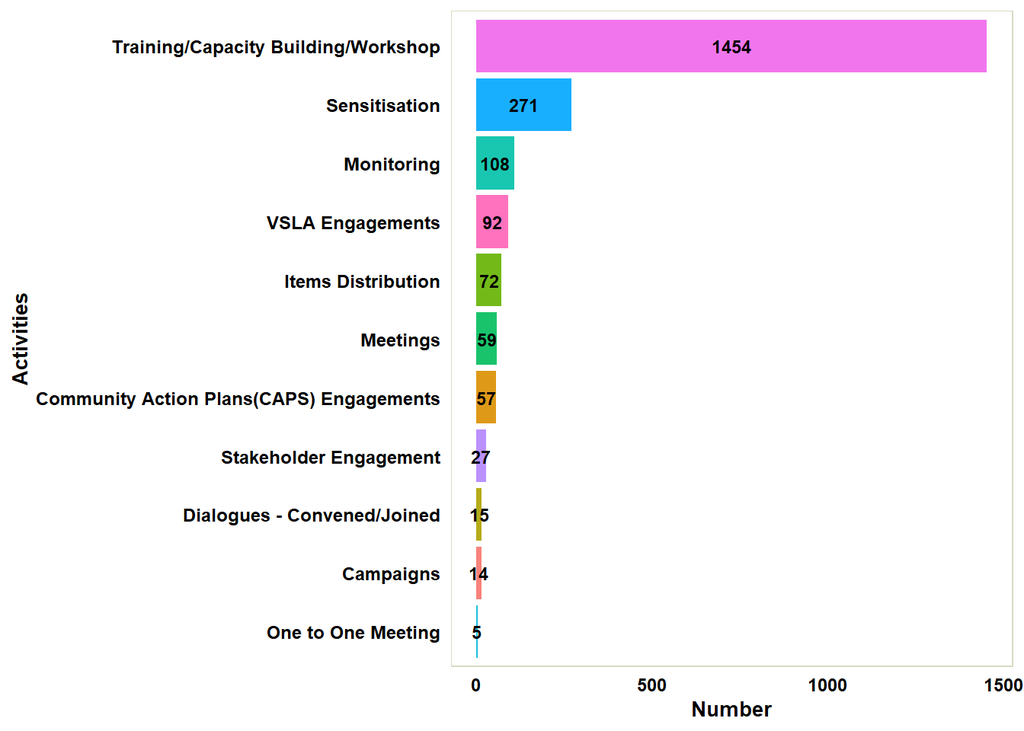

Majority of the activities conducted within the REC from January are related to training and sensitisation. Most of the training in the REC have been contributed from Ghana and Nigeria.

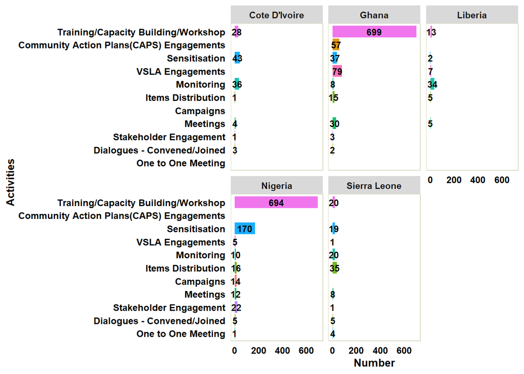

# 2 Number of Activities per Project

The number and types of activities carried out in the REC from January 2023 to date in project is found in the table below. It is evident that the heavy training is mainly contributed by the following projects in Ghana - COCOLIFE, ACTING NOW and NORAD.

No. of Activities per Project

| countryid | projectname | activitytype | count |
| --- | --- | --- | --- |
| Cote D'Ivoire | A&D | Training/Capacity Building/Workshop | 5 |
| Cote D'Ivoire | CLMRS | Monitoring | 3 |
| Cote D'Ivoire | COCOLIFE | Meetings | 2 |
| Cote D'Ivoire | COCOLIFE | Monitoring | 27 |
| Cote D'Ivoire | COCOLIFE | Sensitisation | 12 |
| Cote D'Ivoire | COCOLIFE | Stakeholder Engagement | 1 |
| Cote D'Ivoire | COCOLIFE | Training/Capacity Building/Workshop | 4 |
| Cote D'Ivoire | GIZ COTTON | Items Distribution | 1 |
| Cote D'Ivoire | GIZ COTTON | Monitoring | 6 |
| Cote D'Ivoire | GIZ COTTON | Sensitisation | 24 |
| Cote D'Ivoire | GIZ COTTON | Training/Capacity Building/Workshop | 3 |
| Cote D'Ivoire | PATHWAYS TO PROSPERITY | Training/Capacity Building/Workshop | 1 |
| Cote D'Ivoire | RECLAIM COTE DIVOIRE | Dialogues - Convened/Joined | 3 |
| Cote D'Ivoire | RECLAIM COTE DIVOIRE | Meetings | 2 |
| Cote D'Ivoire | RECLAIM COTE DIVOIRE | Sensitisation | 7 |
| Cote D'Ivoire | RECLAIM COTE DIVOIRE | Training/Capacity Building/Workshop | 15 |
| Ghana | ACTING NOW | Meetings | 23 |
| Ghana | ACTING NOW | Sensitisation | 1 |
| Ghana | ACTING NOW | Training/Capacity Building/Workshop | 130 |
| Ghana | BETTER CHICKEN | Meetings | 2 |
| Ghana | BETTER CHICKEN | Training/Capacity Building/Workshop | 2 |
| Ghana | BETTER CHICKEN | VSLA Engagements | 32 |
| Ghana | COCOA JUICE | Sensitisation | 1 |
| Ghana | COCOLIFE | Community Action Plans(CAPS) Engagements | 57 |
| Ghana | COCOLIFE | Dialogues - Convened/Joined | 1 |
| Ghana | COCOLIFE | Items Distribution | 15 |
| Ghana | COCOLIFE | Meetings | 4 |
| Ghana | COCOLIFE | Monitoring | 8 |
| Ghana | COCOLIFE | Sensitisation | 31 |
| Ghana | COCOLIFE | Stakeholder Engagement | 1 |

[output cut: 69 more lines]

# 3 Activities and Project Participant Types

As at the end of third quarter,farmers were the primary beneficiaries of the activities carried out , followed by community members, VSLA groups, and other kinds of project participants, as shown in the graphs below, however, different projects have reached diverse types of target groups.

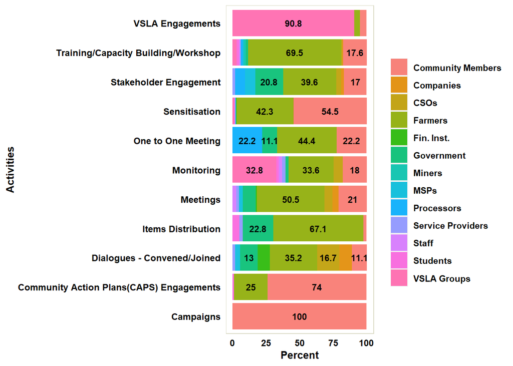

# 4 Participants Engaged by the Various Projects in the REC

The graph below presents a distribution of the various project participants engaged per project.

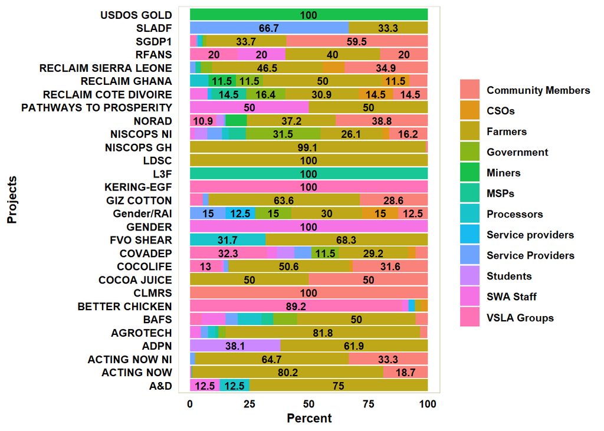

# 5 Number of Project Participants - Training & Meetings

As at end of the third quarter, the REC currently has close to a 50:50 male to female ratio for the individual direct project participants. KERING-EGF in Ghana has the highest proportion (100%) of women, given the project is focused on females in mining communities followed by FVO SHEA(99.1%) and then Gender RAI (88.2%) in Sierra Leone. Nigeria has the highest proportion of target project participants (57.4%) to be females followed by Ghana(49.8%).

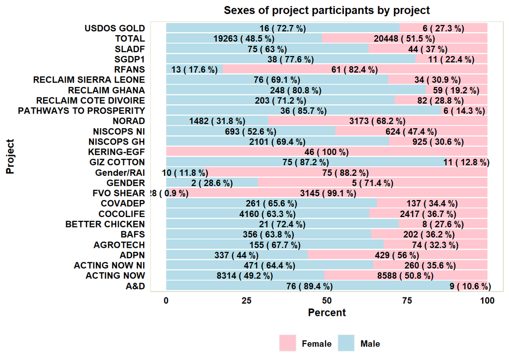

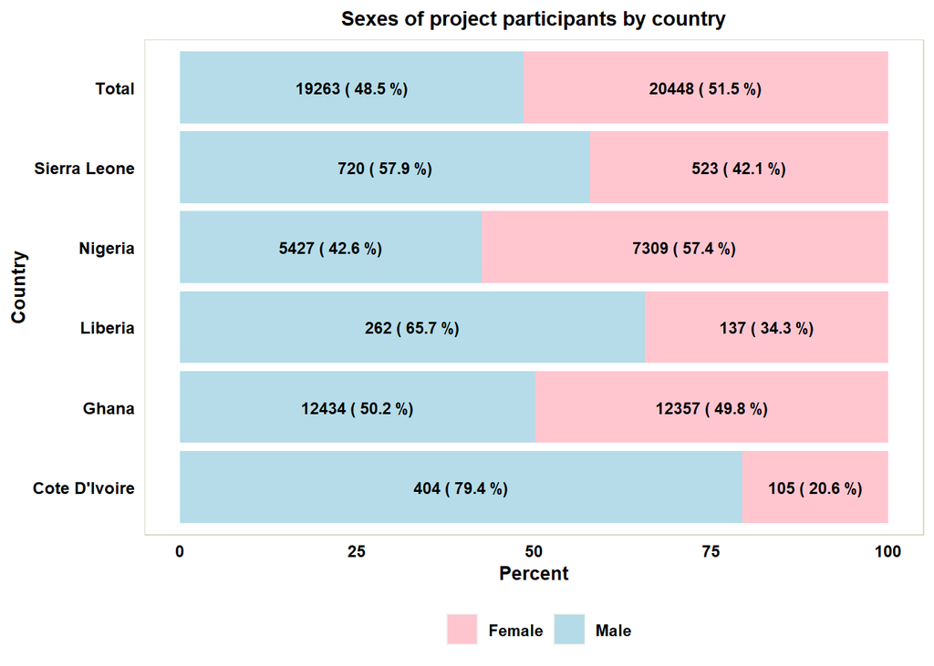

# 6 Dialogues

The table below summarizes the policy issues discussed during multi-stakeholder dialogues mostly from our Reclaim Sustainability Projects and the Gender RAI project in Sierra Leone.

Dialogue Details

| countryid | projectname | commodity | dialoguetype | noofparticipants | nopartners | dialoguepolicy | dialoguepolicyissue | policylevels |
| --- | --- | --- | --- | --- | --- | --- | --- | --- |
| Cote D'Ivoire | RECLAIM COTE DIVOIRE | Oil Palm | Joined | 18 | 6 | National oilpalm policy | La norme des petits exploitants | Capacity to implement policy developed |
| Cote D'Ivoire | RECLAIM COTE DIVOIRE | Cocoa | Joined | 36 | 26 | Child labor/Forced Labour | La protection de l'enfant | Capacity to implement policy developed |
| Ghana | COCOLIFE | Cocoa | Convened | 12 | 2 | Cocoa Value chain policy | Cocoa value chain labour services | Capacity to implement policy developed |
| Nigeria | SGDP1 | Fruits and Vegetables | Convened | 20 | 5 | Gender | Gender incusivity and GAP | Multi-stakeholder dialogue platform convened / policy dialogue started |
| Cote D'Ivoire | RECLAIM COTE DIVOIRE | Cocoa Oil Palm | Joined | 22 | 12 | Forest policy | La réglementation de l'EU sur la déforestation | Multi-stakeholder dialogue platform convened / policy dialogue started |
| Ghana | RECLAIM GHANA | Cocoa | Convened | 32 | 4 | Price mechanism | Formation of Regional Cocoa Cooperative Unions for effective advocacy towards institutionalisation of price mechanisms | Policy recommendations submitted to decision makers, and under consideration |
| Nigeria | ADPN | Aquaculture | Joined | 35 | 2 | Sanitation | Farmers Cooperative Societies. | Agenda Setting |
| Nigeria | ADPN | Aquaculture | Convened | 49 | 2 | Sanitation | Cooperative Formation & Administration. | Policy recommendations submitted to decision makers, and under consideration |
| Nigeria | ADPN | Aquaculture | Joined | 45 | 2 | Sanitation | Group Management | Capacity to implement policy developed |
| Sierra Leone | Gender/RAI | Fruits Maize Potatoes Rice Okro Pepper Garden eggs Cabbage Tomatoes Onions Groundnut Cassava | Convened | 45 | 15 | Land policy | Women inclusion to foster their participation in Responsible Agricultural Investments. | Capacity to engage in advocacy developed |
| Sierra Leone | Gender/RAI | Cabbage Tomatoes Onions Pepper Rice Groundnut Cassava Sweetcorn Garden eggs Okro | Convened | 45 | 15 | Gender | Women's Empowerment to engage in RAI, Access to land | Multi-stakeholder dialogue platform convened / policy dialogue started |
| Sierra Leone | Gender/RAI | Maize Potatoes Rice Okro Pepper Garden eggs Sweetcorn Groundnut Cassava Oil Palm | Convened | 45 | 15 | Land policy | Empowering rural women to engage in RAI, Access to land, Gender equality | Multi-stakeholder dialogue platform convened / policy dialogue started |
| Sierra Leone | Gender/RAI | Maize Fruits Potatoes Rice Okro Pepper Garden eggs Cabbage Tomatoes Onions Sweetcorn Groundnut Cassava | Convened | 45 | 15 | Gender | Women's Empowerment to engage in RAI, Access to land, Gender equality | Multi-stakeholder dialogue platform convened / policy dialogue started |
| Sierra Leone | Gender/RAI | Fruits Maize Potatoes Rice Okro Pepper Garden eggs Cabbage Tomatoes Onions Sweetcorn Groundnut Cassava | Convened | 45 | 15 | Gender | Empowering grassroot rural women to engage in Responsible Agricultural Investments, Gender equality and Women's right and Access to land | Multi-stakeholder dialogue platform convened / policy dialogue started |
| Nigeria | SGDP1 | Fruits Okro Pepper Cabbage Tomatoes Onions | Convened | 6 | 3 | Price mechanism | The discussion was to create aggregation center in the community where farmers can take their produce to every two days while off takers from South west and east comes there to buy. | Policy recommendations fully / effectively implemented |

# 7 Sensitisation

Similar to direct beneficiaries, sensitizations carried out in Nigeria and Sierra Leone presently have almost equal proportion of estimated reach of males and females.

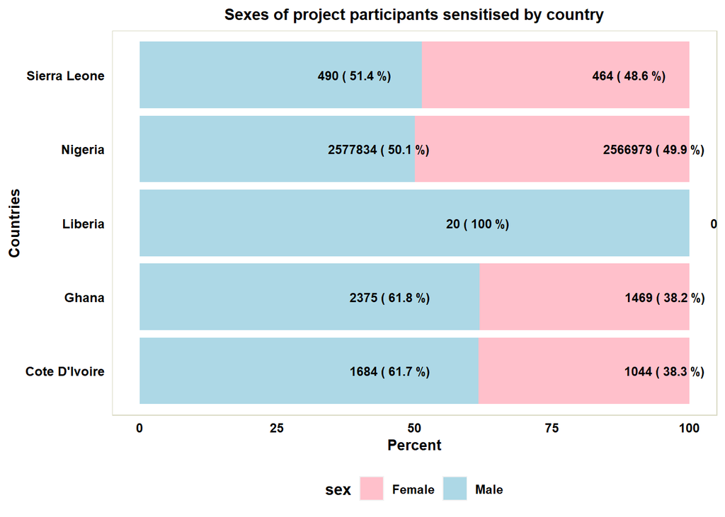

The sensitization campaigns have focused mostly on climate smart agriculture , child labor, home gardening,land policies, sanitation, gender issues, and promoting fruit and vegetables as a business

No. of Policies per Project

| countryid | projectname | policies | nooftimes |
| --- | --- | --- | --- |
| Cote D'Ivoire | COCOLIFE | Child labor/Forced Labour | 12 |
| Cote D'Ivoire | COCOLIFE | Child protection | 7 |
| Cote D'Ivoire | GIZ COTTON | Child labor/Forced Labour | 16 |
| Cote D'Ivoire | GIZ COTTON | Climate Smart Agriculture | 1 |
| Cote D'Ivoire | GIZ COTTON | Gender | 5 |
| Cote D'Ivoire | GIZ COTTON | Home Gardening | 1 |
| Cote D'Ivoire | GIZ COTTON | Land policy | 2 |
| Cote D'Ivoire | RECLAIM COTE DIVOIRE | Child labor/Forced Labour | 5 |
| Cote D'Ivoire | RECLAIM COTE DIVOIRE | Child protection | 1 |
| Ghana | ACTING NOW | Climate Smart Agriculture | 1 |
| Ghana | COCOA JUICE | Climate Smart Agriculture | 1 |
| Ghana | COCOA JUICE | Cocoa Value chain policy | 1 |
| Ghana | COCOLIFE | Child labor/Forced Labour | 15 |
| Ghana | COCOLIFE | Child protection | 16 |
| Ghana | COCOLIFE | Climate Smart Agriculture | 13 |
| Ghana | COCOLIFE | Drug abuse | 7 |
| Ghana | COCOLIFE | Forest policy | 3 |
| Ghana | COCOLIFE | Gender | 13 |
| Ghana | COCOLIFE | Land policy | 2 |
| Ghana | COCOLIFE | Pesticide use | 4 |
| Ghana | COCOLIFE | Sanitation | 21 |
| Ghana | COCOLIFE | Sustainable ASM policy | 1 |
| Liberia | COVADEP | Climate Smart Agriculture | 2 |
| Nigeria | ACTING NOW | Climate Smart Agriculture | 13 |
| Nigeria | ACTING NOW | Fruit & Vegetable Business | 3 |
| Nigeria | ACTING NOW | Gender | 12 |
| Nigeria | ACTING NOW | Home Gardening | 7 |
| Nigeria | ACTING NOW | Nutrition Sensitive Agriculture | 8 |
| Nigeria | ACTING NOW | Pesticide use | 2 |
| Nigeria | ACTING NOW NI | Fruit & Vegetable Business | 4 |
| Nigeria | ACTING NOW NI | Gender | 1 |
| Nigeria | ADPN | Climate Smart Agriculture | 1 |
| Nigeria | NISCOPS NI | Forest policy | 2 |
| Nigeria | SGDP1 | Child protection | 5 |
| Nigeria | SGDP1 | Climate Smart Agriculture | 77 |
| Nigeria | SGDP1 | Cocoa Value chain policy | 1 |
| Nigeria | SGDP1 | Forest policy | 2 |
| Nigeria | SGDP1 | Fruit & Vegetable Business | 46 |
| Nigeria | SGDP1 | Gender | 56 |
| Nigeria | SGDP1 | Home Gardening | 39 |
| Nigeria | SGDP1 | Land policy | 7 |
| Nigeria | SGDP1 | Nutrition Sensitive Agriculture | 45 |
| Nigeria | SGDP1 | Pesticide use | 1 |
| Nigeria | SGDP1 | Price mechanism | 1 |
| Nigeria | SGDP1 | Sanitation | 19 |
| Sierra Leone | AGROTECH | Climate Smart Agriculture | 4 |
| Sierra Leone | AGROTECH | Forest policy | 2 |
| Sierra Leone | AGROTECH | Land policy | 2 |
| Sierra Leone | RECLAIM SIERRA LEONE | Forest policy | 3 |
| Sierra Leone | RECLAIM SIERRA LEONE | Gender | 5 |
| Sierra Leone | RECLAIM SIERRA LEONE | Land policy | 7 |

# 8 Campaigns

Campaigns have mainly been carried out by the SGDP team.

Campaigns Conducted

| countryid | projectname | campaignmedium | campaignreach | campaigntarget | campaingmessage | campaingpolicy |
| --- | --- | --- | --- | --- | --- | --- |
| Nigeria | SGDP1 | Radio | 12000 | Farmers | Farmers (youth and women) to participate and make it a business | Gender |
| Nigeria | SGDP1 | Radio | 12000 | Farmers | Taking farming as business | Land policy |
| Nigeria | SGDP1 | Radio | 1500000 | Farmers | Encouraging audience to keep listening to the program as interesting topics will be discussed in 2023 | Gender |
| Nigeria | SGDP1 | Radio | 1500000 | Farmers | All forms of gender should venture into vegetable farming to bridge the gap and transform the Nigeria's veg market | Gender |
| Nigeria | SGDP1 | Radio | 15000000 | Farmers | Importance of forming VSLA groups | Gender |
| Nigeria | SGDP1 | Radio | 1500000 | Farmers | Importance of Nutrition sensitive Agriculture | Land policy |
| Nigeria | SGDP1 | Radio | 1500000 | Famers | Importance of establishing home gardening | Gender |
| Nigeria | SGDP1 | Radio | 1500000 | Farmers | Effect of pesticides on human body and plants | Pesticide use |
| Nigeria | SGDP1 | Radio | 15 | Smallholder vegetable farmers and their hh | Raising good seedlings towards healthy home gardening | Gender |
| Nigeria | SGDP1 | Radio | 1000500 | Smallholder vegetable farmers Vegetable value chain actors Policy makers General public | Best practices in fertilizer application of vegetable crops | Gender |
| Nigeria | SGDP1 | Radio | 1000500 | Farmer HH Smallholder Vegetable farmers Policy makers General public | Soil nutrients and crop nutrients requirements are supposed to be understood side by side nutrient application | Gender |
| Nigeria | SGDP1 | Radio | 1000500 | Smallholder vegetable farmers Farmer HH Policy makers General public | Proper identification of diseases and best chemicals for it | Gender |
| Nigeria | SGDP1 | Radio | 1000500 | General punlic Farmer HH | Embrace the VSLA for icreased production an improved livelihood | Gender |
| Nigeria | SGDP1 | Radio | 1000500 | Smallholder farmers Farming HH General public | Farmers should engage in practuces that are climate friendly | Gender |

# 9 VSLA Engagements

Since January, a total of 92 VSLA engagements have been executed, most of which were done under the Cocolife project in Ghana.

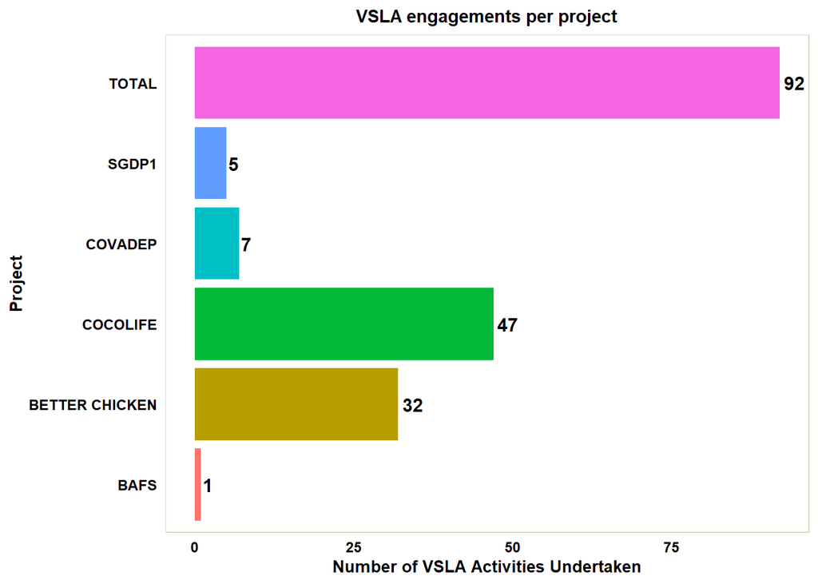

The VSLA reports submitted so far for this year are mostly pertaining to VSLA Activity tracking.

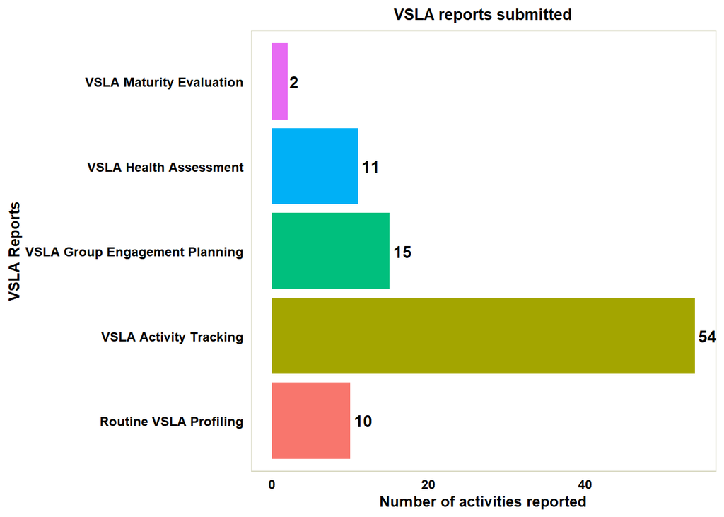

Backstopping was the most prevalent form of assistance provided to VSLAs during facilitation visits by both the Cocoalife and Better Chicken projects.

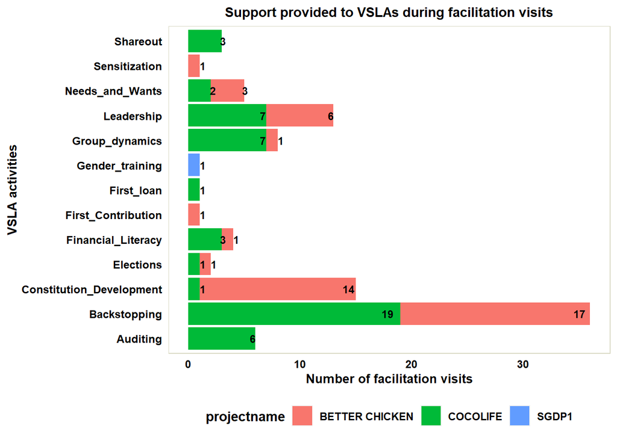

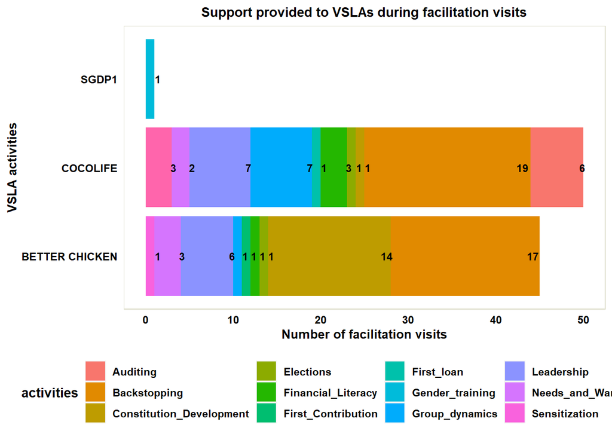

# 10 Items Distributed

As at the end of the third quarter, various items including agrochemicals , pruning tools , sprouted seeds , fertilizers, seedlings and VSLA boxes have been distributed to project participants across five projects as shown in the graph below :

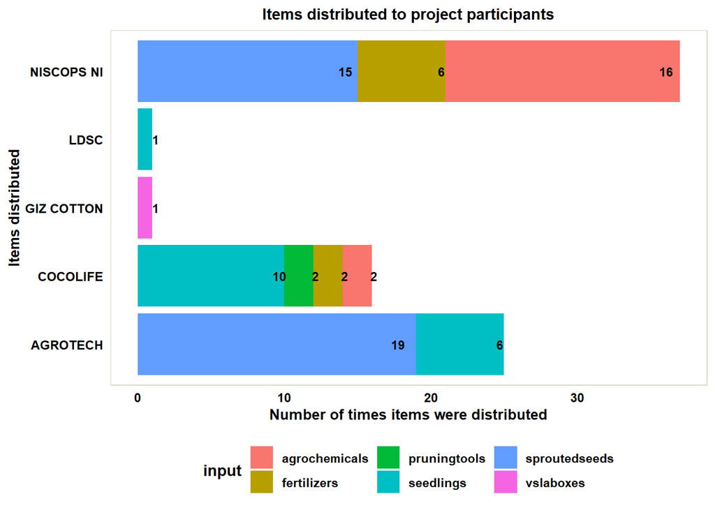

# 11 Stakeholder engagements

Since January , a total of 27 stakeholder engagements have been organised within the REC with most of them being facilitated by the Acting Now and NISCOPS projects in Nigeria.

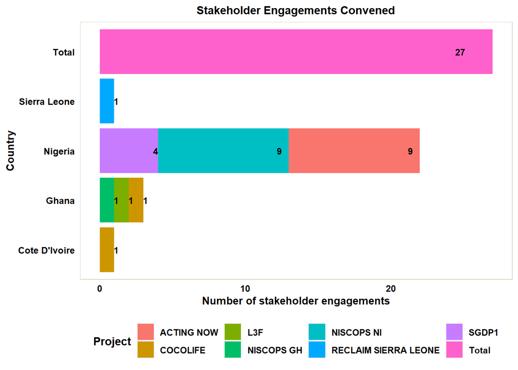

The table below presents an overview of key issues discussed and the institutions involved in these stakeholder engagements.

**Stakeholder Engagements**

| Country | Project | Convenor | Issue | Institutions |
| --- | --- | --- | --- | --- |
| Ghana | NISCOPS GH | Other Project Stakeholder | Prioritization of livelihood options selected during phase 1 | Solidaridad West Africa Plantation Socfinaf Ghana (PSG) |
| Nigeria | NISCOPS NI | Solidaridad West Africa | Forest status in the state and protection strategy,sustained advocacy visit to communities and relevant govt MDAs and support to farmers. | Ministry of Agric,REDD++,Forestry Commission,Ministry of Environment,Traditional rulers,CSOs and MSP members |
| Nigeria | SGDP1 | Solidaridad West Africa | Price of fruits and vegetables in the market, relationship between the market and farmers and union leaders | Market union leaders, market leaders, government price regulators |
| Nigeria | SGDP1 | Solidaridad West Africa | Prices of fruits and vegetables, market relationship with farmers and other relevant stakeholders | Market leaders, union officials, government price regulators |
| Nigeria | SGDP1 | Solidaridad West Africa | Identifying markets and linking them with fruits and vegetables farmers | Tomato processors, union officials, market leaders and government price regulators |
| Nigeria | SGDP1 | Solidaridad West Africa | Improving the relationship between the market and fruits and vegetables farmers | Farmers, market leaders, union officials and processors |
| Nigeria | ACTING NOW | Solidaridad West Africa | Food insecurity, climate change effects on potato production and the need for training of potato farmers | Solidaridard |
| Nigeria | ACTING NOW | Solidaridad West Africa | Food insecurity, training of potato farmers on good agricultural practices, climate change, access to good market, access to farm input. | Solidaridard West Africa |
| Nigeria | ACTING NOW | Solidaridad West Africa | Food insecurity, climate change, access to good market, training of potato farmers on good agricultural practices. | Solidaridard |
| Nigeria | ACTING NOW | Solidaridad West Africa | Food insecurity, training of potato farmers, market, climate change, good agricultural practices. | Solidaridard West Africa |
| Nigeria | ACTING NOW | Solidaridad West Africa | Need for training of potato farmers on good agricultural practices in order to achieve food security | Solidaridard West Africa |
| Nigeria | ACTING NOW | Solidaridad West Africa | Effects of Climate change on crop production, need for training of potato on good agricultural practices, access to good market, access to farm inputs. | Solidaridard West Africa |
| Nigeria | ACTING NOW | Solidaridad West Africa | How to mobilize farmers for sensitization and for Good Agricultural Practices trainings | NA |
| Nigeria | ACTING NOW | Solidaridad West Africa | We introduced the "Acting now" project which is aimed at training 2000 potato farmers to achieve the following: Increased productivity. Inproved access to inputs, seedlings and services. Improved acce… | Ward head, community leader and key farmers |
| Nigeria | ACTING NOW | Solidaridad West Africa | We introduced the "Acting Now" project to their them, we seek their consent and also plead for their support by mobilizing farmers for sensitization | N A |
| Nigeria | NISCOPS NI | Other Project Stakeholder | The issue of exclusion of women and youth in the ownership of farm lands, processing facilities and houses. Also, the negative impact of deforestation to the ecosystem and the need to protect the exis… | Ministry of Women Affairs |
| Nigeria | NISCOPS NI | Solidaridad West Africa | 1. Introduction of SWA and her work in the state. 2. The state of oil palm farming in the state 3. Forest degradation and proposed remedies 4. Need for the Ministry to engage in policy enforcement to … | Ministry of Environment |
| Sierra Leone | RECLAIM SIERRA LEONE | Solidaridad West Africa | The Reclaim Sustainability 2024 Milestones and generating key activities for the 2024 work plan | MAF, SLPMB, SLPMC, CSSL, FT SAAD, WIMSAL, KITOPFCO, SEND-SL, ECC, and Farmer groups |
| Nigeria | NISCOPS NI | Solidaridad West Africa | 1. Introduction of Solidaridad and her work in the state. 2. Issues around gender inclusivity in the oil palm sector 3. Issues around forest protection 4. The need for the state's budgets on oil palm … | Ministry of Agriculture and Natural Resources |
| Nigeria | NISCOPS NI | Solidaridad West Africa | The need for the Commission and other relevant departments and Agencies of Government to review it enact relevant policies and enforce these towards halting indiscriminate deforestation which impacts … | 1. Forestry Commission 2. REDD Plus |
| Nigeria | NISCOPS NI | Solidaridad West Africa | 1. Imperatives of increasing budgetary allocation and corresponding releases to the oil palm sector to complement the efforts of Solidaridad to the smallholder farmers 2. Issues around exclusion of wo… | Nkanu West LG Council. Traditional Rulers Farmers |
| Nigeria | NISCOPS NI | Solidaridad West Africa | 1. Imperatives of increasing budgetary allocation and corresponding releases to the oil palm sector to complement the efforts of Solidaridad to the smallholder farmers 2. Issues around exclusion of wo… | Udenu LOcal Government Council |
| Nigeria | NISCOPS NI | Solidaridad West Africa | 1. Imperatives of increasing budgetary allocation and corresponding releases to the oil palm sector to complement the efforts of Solidaridad to the smallholder farmers 2. Issues around exclusion of wo… | Aninri Local Government Council Traditional Rulers Farmers |
| Ghana | COCOLIFE | Solidaridad West Africa | Caps activities in the community | Chief and elders, union leaders, community members, district assembly staff |
| Nigeria | NISCOPS NI | Solidaridad West Africa | Forest protection, sustainable oil palm production and green plan policy | Enugu state House of Assembly Traditional Rulers Council Ministry of Agriculture and Agro industrialization Ministry of Environment Enugu state Forestry Commission |
| Cote D'Ivoire | COCOLIFE | Other Project Stakeholder | Observations sur les modules GENRE qui feront l'objet de formation aux étudiants de l'ESA | SOLIDARIDAD ESA MEMINADER MFFE ONU FEMME ONEG PNUD PGA-CI 2PAI-B CHAIRE UNESCO FIRCA DIRECTION EN CHARGE DU GENRE ET DE L'ÉQUITÉ DU MFFE |
| Ghana | L3F | Solidaridad West Africa | Reflection on 9 months of 2023 activities and planning for 2024 activities | 1. GADAK Agro Services 2. Purity and Integrity Company Limited 3. Sinapi Aba Savings and Loans 4. Touton SA 5. EMFED Farms 6. Agrisces Consult 7. Koaklina 8. AgriDepot 9. Solidaridad West Africa |